# PSet 4

Junyi Yao, Yuezhu Xu

Note: Grading is based both on your graphs and verbal explanations. Follow all best practices *as discussed in class*, including choosing appropriate parameters for all graphs. *Do not expect the assignment questions to spell out precisely how the graphs should be drawn. Sometimes guidance will be provided, but the absense of guidance does not mean that all choices are ok.*

IMPORTANT: THIS TEMPLATE DOES NOT INCLUDE THE SAMPLE GRAPHS THAT APPEAR IN THE .HTML VERSION OF THE ASSIGNMENT SO BE SURE TO VIEW THAT FILE AS WELL.

Loading Packages

```r
library(tidyverse)
library(patchwork)
library(ggnewscale)
library(Lock5withR)
```

### 1. `mycars` missing patterns

Create a missing values plot for the `mycars` dataset created below (slightly different from the one in the lecture slides). Your plot should be in the style of `extracat::visna()` (no longer available on CRAN) using **ggplot2** to create the main plot and two side plots and **patchwork** to put them together. It should show accurately: missing patterns, counts for missing by column and missing by pattern, and make it clear which row respresents complete cases. Bars in the side plots should be sorted and correspond to the rows and columns of the main plot. An example is provided though the aesthetics of your plot do not have to conform precisely to the example. Some code is provided to get you started with finding missing patterns. (Keep in mind that in the next question you will be turning this code into a function so to save yourself time later on write as generically as possible.)

```r
# Add NAs to mtcars dataset
set.seed(5702)
mycars <- mtcars
mycars[1:25, "gear"] <- NA
mycars[10:20, 3:5] <- NA
for (i in 1:10) mycars[sample(32,1), sample(11,1)] <- NA
```

**Hints:**

- You can use this code to find and count the missing patterns:

```r
missing_patterns <- data.frame(is.na(mycars)) %>%
  group_by_all() %>%
  count(name = "count", sort = TRUE) %>%
  ungroup()
```

- To highlight the complete cases row you need a different fill scale than the one used to show missing vs. non-missing in the main plot (purple and grey in the example). This is a little tricky since you’re only allowed one fill scale in **ggplot2**. You can either use `alpha` to control the highlight with `scale_alpha_manual(values = ...)` or use the **ggnewscale** package which provides for multiple fill scales in the same graph.

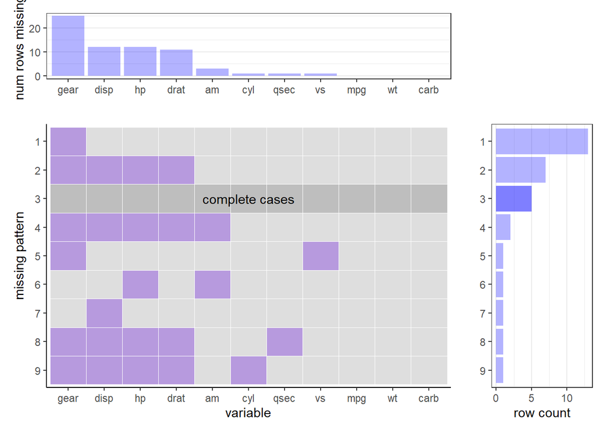

```r
# Add NAs to mtcars dataset
set.seed(5702)
mycars <- mtcars
mycars[1:25, "gear"] <- NA
mycars[10:20, 3:5] <- NA
for (i in 1:10) mycars[sample(32,1), sample(11,1)] <- NA


missing_patterns <- data.frame(is.na(mycars)) %>%
  group_by_all() %>%
  count(name = "count", sort = TRUE) %>%
  ungroup()

missing_patterns_large <- missing_patterns[,-length(missing_patterns)]
order <- sort(colSums(missing_patterns_large), decreasing = TRUE)
missing_patterns_tidy <- missing_patterns_large %>% rownames_to_column("pattern") %>%
  gather(variable, missing, -pattern)

missing_patterns_tidy$missing<-as.numeric(missing_patterns_tidy$missing)

missing_patterns_tidy$variable <- factor(missing_patterns_tidy$variable,levels = names(order))
allexist <- which(rowSums(missing_patterns_large)==0)
missing_patterns_tidy[missing_patterns_tidy$pattern==allexist,]$missing<-2

middle<-ceiling(length(levels(missing_patterns_tidy$variable))/2)

#y-axis need to be sorted by numbers, not by character (string of numbers)
missing_patterns_tidy$pattern<- factor(missing_patterns_tidy$pattern,
                                       levels = unique(sort(as.numeric(missing_patterns_tidy$pattern))))

#the graph at the left down corner
p1<-ggplot(data = missing_patterns_tidy,
       mapping = aes(x = fct_reorder(variable, -missing, sum), y = fct_rev(pattern), fill = factor(missing))) +
  geom_tile(color = "white")+
  scale_fill_manual(values = c(alpha('grey', 0.5), alpha('#B79ADE',1), alpha('grey',1)))+
  xlab('variable')+ylab('missing pattern')+
  annotate("text",x = levels(missing_patterns_tidy$variable)[middle] ,y = as.character(allexist),label = "complete cases")+
  theme_classic() + guides(fill = "none")


NA_nums<-colSums(data.frame(is.na(mycars)))
upper<-data.frame(NA_nums) %>% rownames_to_column('variable')
upper<-upper[order(upper[,2], decreasing =TRUE),]
#the graph at the left up corner
p2<-ggplot(upper, aes(x = fct_inorder(variable), y=NA_nums))+geom_col(fill = 'blue', alpha = 0.3)+
  scale_y_continuous(breaks = seq(0,max(upper$NA_nums),10))+
  xlab('')+ylab('num rows missing:')+
  theme_bw()+theme(panel.grid.major.x=element_blank())


missing_patterns_right<-missing_patterns %>% rownames_to_column("pattern")
right <- missing_patterns_right[c('pattern','count')]
#set alpha
right$special <- 0
right[right$pattern == allexist,]$special <- 1
#the graph at the right down corner
p3<-ggplot(right)+
  geom_col(mapping = aes(x = fct_rev(fct_inorder(pattern)), y = count, alpha = factor(special)),
                         fill= 'blue')+
  scale_alpha_manual(values = c(0.3,0.5))+
  theme_bw()+theme(panel.grid.major.y=element_blank())+
  theme(legend.position = "none")+
  ylab('row count')+xlab('')+coord_flip()

#arrange three graghs
p2 + plot_spacer() + p1 + p3 + plot_layout(height = c(1,4), widths = c(4,1))
```

The graph accurately shows that there are nine missing patterns and the counts of each missing pattern are shown in the right in descending order. Also in the upper graph, it demonstrates the counts for missing by column in descending order. Besides, the row for complete cases are clearly presented in the plot with color in darker grey.

### 2. Missing value plot function

1. Create a function for creating missing plots based on your code from question 1. It should provide an option to show either missing counts or missing percent. The percent option for `mycars` is shown below.

You either put the function code in a separate `.R` file or include it in the `.Rmd` file.

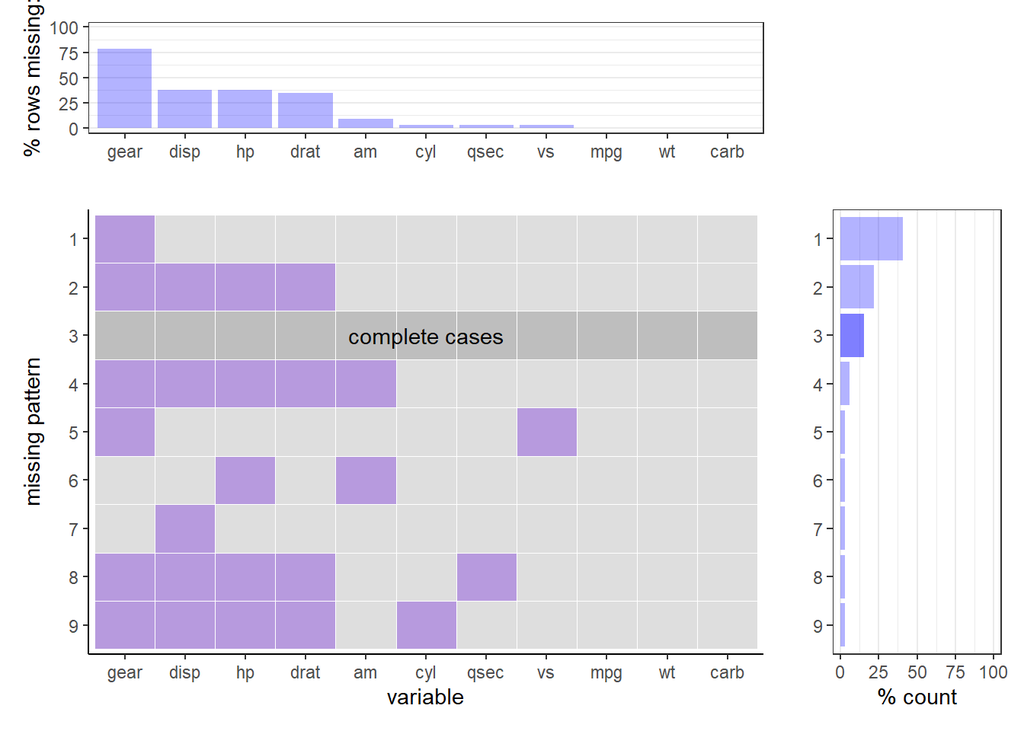

```r
source("plot_missing.R")
plot_missing(mycars, percent = TRUE)
```

We created the function plot_missing in the “plot_missing.R” and the percentage graph is shown above.

2. Show the output for both options (counts / percent) for the `economics` dataset in the **ggplot2** package. (This is a test to see if your function works if there are no missing values.)

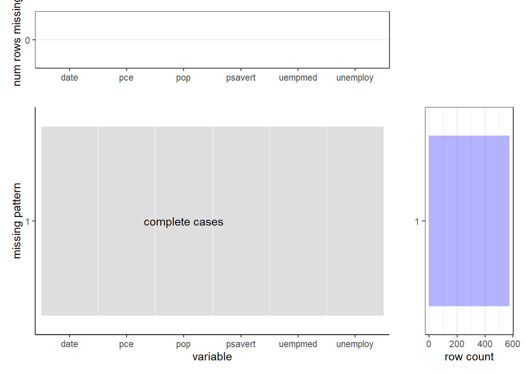

```r
plot_missing(economics, percent = FALSE)
```

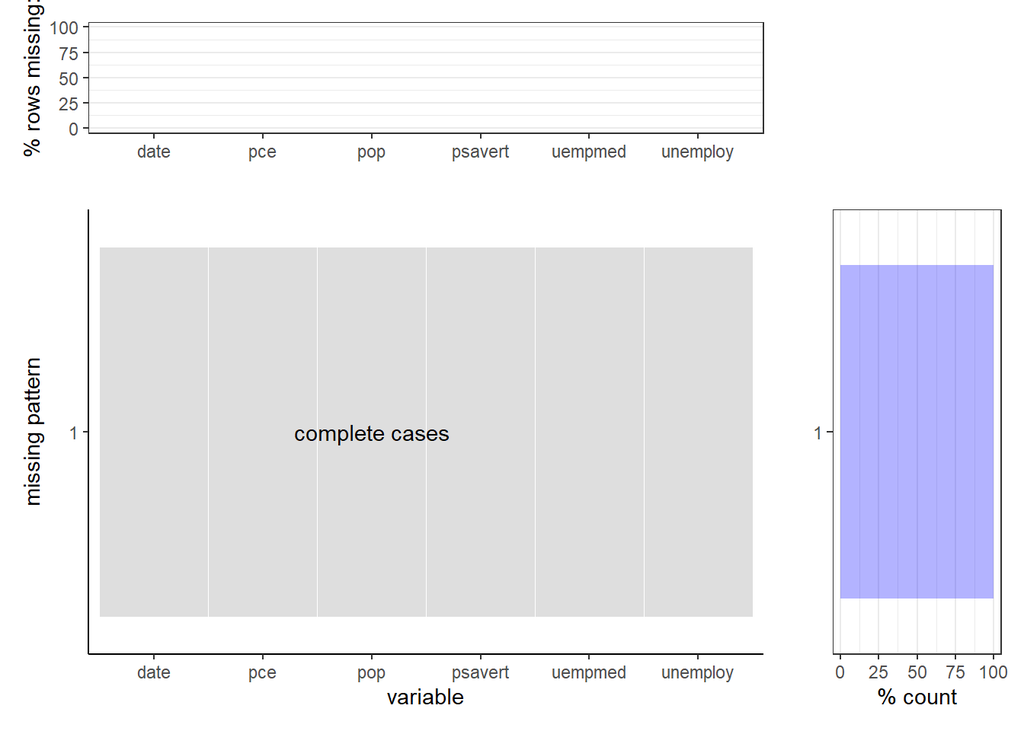

```r
plot_missing(economics, percent = TRUE)
```

As we can see, the function still works when there is no NA. All data are in only one missing pattern and it is complete case.

3. Show the output for both options (counts / percent) for the `HollywoodMovies2011` dataset in the **Lock5withR** package. You can shorten the column names so they don’t overlap in the plot.

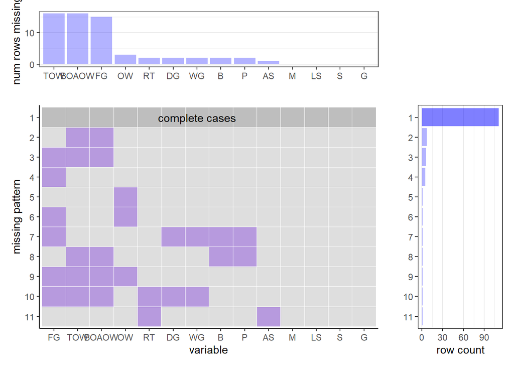

```r
colnames(HollywoodMovies2011)<-c('M','LS','RT','AS','S','G','TOW','BOAOW','DG','FG','WG','B','P','OW')
plot_missing(HollywoodMovies2011, percent = FALSE)
```

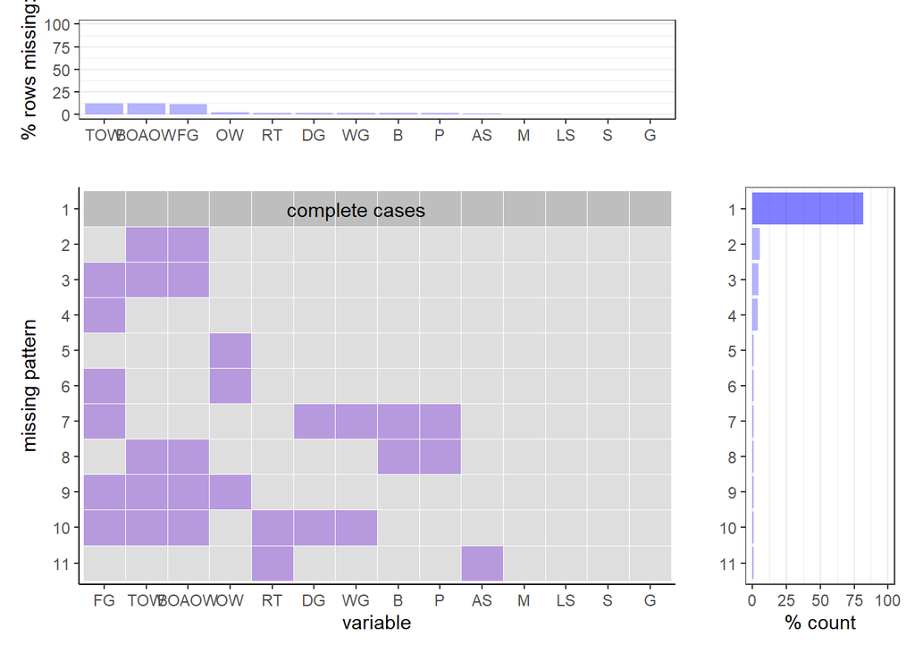

```r
plot_missing(HollywoodMovies2011, percent = TRUE)
```

To avoid overlap in the plot, we shortened the column names as shown above. There are 11 cases and in most cases, there is no NA (complete cases are the majority represented by the first row).

### 3. Setup your GitHub final project repo

1. Set up your final project repository following the [EDAVproject template](https://github.com/jtr13/EDAVtemplate). You can either choose one team member’s GitHub account, or create an organization to house the final project. *Be sure to follow all of the steps in the README so your bookdown book renders with your information, not the placeholders in the template.* Edit the link below to point to your rendered book:

https://junyi-yao.github.io/education_and_income

2. Make sure that all team members have write access to the repository and have practiced making contributions. Edit the link below to point to your contributors page, showing that all team members have made contributions to the repo (Note that we do not have the ability to see who has write access, only who has contributed):

https://github.com/junyi-yao/education_and_income/graphs/contributors

3. Discuss a plan for dividing up the work for the final project and briefly summarize what each person will do.

#### Junyi Yao will do the following:

calculate the proportion of people that make different income for each education attainment type. Make density histogram that shows the distribution of income for different education attainments.

for people that make the highest and lowest income, make density histogram that shows the distribution of their education attainment.

Use gender as facet, create ridgeline plot of education attainment and personal income. Use education attainment as facet, make ridgeline plot of gender and personal income.

create parallel coordinate plot of gender, education and income.

*Build the “Data Sources”, “Results” and “Conclusion” pages*

#### Yuezhu Xu will do the following:

create an alluvial diagram of : gender–> education attainment –> personal income

create a stacked bar chart of personal income for people with different education attainment

Use education attainment as facet, create stacked bar chart for men and women with different personal income

do every graph for each year, see if there is any pattern with time.

Try to make the graphs interactive(option for year, gender etc.)

*Build the “Introduction”, “Data Transformation”, and “Interactive Component” pages*

### 4. Missing values chapter

Write a first draft of the missing values chapter of your final project. You do not have to include all of the data you use in the final project. Choose one file and analyze it using techniques discussed in class for missing values. Include a plot using your function from Q2 as well as verbal interpretation of the plot. Edit this link to point to your chapter:

https://junyi-yao.github.io/education_and_income/missing-values.html

**If your data for the final project has no missing values, you may use one of the following datasets instead for this question. You can include your answer here since it doesn’t belong in your final project.**

**fivethirtyeight** package: `avengers`, `bachelorette`, `dem_candidates`, `steak_survey`, `trumpworld_polls`

**openintro** package: `birds`, `ucla_textbooks_f18`